# WINE QUALITY PREDICTION

This notebook serves as the documentation for the development of machine learning models for predicting the quality of wine based of its various properties such as alcohol,chlorides etc.The workflow includes verious steps such as data loading,preprocessing,feature engineering and training various models to evaluate their performance.

## DATA LOADING

The red and white wine datasets are loaded and merged into single dataset with additional column to distinguish between wines.

```python
#importing libraries
import pandas as pd
import numpy as np
import seaborn as sns
import matplotlib.pyplot as plt
from sklearn.preprocessing import StandardScaler,MinMaxScaler
from imblearn.over_sampling import SMOTE
from sklearn.svm import SVC
from sklearn.ensemble import  BaggingClassifier
from sklearn.tree import DecisionTreeClassifier
from sklearn.metrics import accuracy_score
from sklearn.model_selection import GridSearchCV
from sklearn.metrics import classification_report
from sklearn.metrics import roc_curve, auc
from sklearn.metrics import confusion_matrix
import warnings
warnings.filterwarnings('ignore')
```

```python
#loading file
file_path = r"D:\Downloads\wine+quality\winequality-red.csv"
red_wine =pd.read_csv(file_path,delimiter=';')
red_wine.head()
```

|  | fixed acidity | volatile acidity | citric acid | residual sugar | chlorides | free sulfur dioxide | total sulfur dioxide | density | pH | sulphates | alcohol | quality |
| --- | --- | --- | --- | --- | --- | --- | --- | --- | --- | --- | --- | --- |
| 0 | 7.4 | 0.70 | 0.00 | 1.9 | 0.076 | 11.0 | 34.0 | 0.9978 | 3.51 | 0.56 | 9.4 | 5 |
| 1 | 7.8 | 0.88 | 0.00 | 2.6 | 0.098 | 25.0 | 67.0 | 0.9968 | 3.20 | 0.68 | 9.8 | 5 |
| 2 | 7.8 | 0.76 | 0.04 | 2.3 | 0.092 | 15.0 | 54.0 | 0.9970 | 3.26 | 0.65 | 9.8 | 5 |
| 3 | 11.2 | 0.28 | 0.56 | 1.9 | 0.075 | 17.0 | 60.0 | 0.9980 | 3.16 | 0.58 | 9.8 | 6 |
| 4 | 7.4 | 0.70 | 0.00 | 1.9 | 0.076 | 11.0 | 34.0 | 0.9978 | 3.51 | 0.56 | 9.4 | 5 |

```python
#initializing new column
red_wine['wine']='red'
red_wine.head()
```

|  | fixed acidity | volatile acidity | citric acid | residual sugar | chlorides | free sulfur dioxide | total sulfur dioxide | density | pH | sulphates | alcohol | quality | wine |
| --- | --- | --- | --- | --- | --- | --- | --- | --- | --- | --- | --- | --- | --- |
| 0 | 7.4 | 0.70 | 0.00 | 1.9 | 0.076 | 11.0 | 34.0 | 0.9978 | 3.51 | 0.56 | 9.4 | 5 | red |
| 1 | 7.8 | 0.88 | 0.00 | 2.6 | 0.098 | 25.0 | 67.0 | 0.9968 | 3.20 | 0.68 | 9.8 | 5 | red |
| 2 | 7.8 | 0.76 | 0.04 | 2.3 | 0.092 | 15.0 | 54.0 | 0.9970 | 3.26 | 0.65 | 9.8 | 5 | red |
| 3 | 11.2 | 0.28 | 0.56 | 1.9 | 0.075 | 17.0 | 60.0 | 0.9980 | 3.16 | 0.58 | 9.8 | 6 | red |
| 4 | 7.4 | 0.70 | 0.00 | 1.9 | 0.076 | 11.0 | 34.0 | 0.9978 | 3.51 | 0.56 | 9.4 | 5 | red |

```python
#loading file
file_path = r"D:\Downloads\wine+quality\winequality-white.csv"
white_wine=pd.read_csv(file_path,delimiter=';')
white_wine.head()
```

|  | fixed acidity | volatile acidity | citric acid | residual sugar | chlorides | free sulfur dioxide | total sulfur dioxide | density | pH | sulphates | alcohol | quality |
| --- | --- | --- | --- | --- | --- | --- | --- | --- | --- | --- | --- | --- |
| 0 | 7.0 | 0.27 | 0.36 | 20.7 | 0.045 | 45.0 | 170.0 | 1.0010 | 3.00 | 0.45 | 8.8 | 6 |
| 1 | 6.3 | 0.30 | 0.34 | 1.6 | 0.049 | 14.0 | 132.0 | 0.9940 | 3.30 | 0.49 | 9.5 | 6 |
| 2 | 8.1 | 0.28 | 0.40 | 6.9 | 0.050 | 30.0 | 97.0 | 0.9951 | 3.26 | 0.44 | 10.1 | 6 |
| 3 | 7.2 | 0.23 | 0.32 | 8.5 | 0.058 | 47.0 | 186.0 | 0.9956 | 3.19 | 0.40 | 9.9 | 6 |
| 4 | 7.2 | 0.23 | 0.32 | 8.5 | 0.058 | 47.0 | 186.0 | 0.9956 | 3.19 | 0.40 | 9.9 | 6 |

```python
#initializing new column
white_wine['wine'] ='white'
white_wine.head()
```

|  | fixed acidity | volatile acidity | citric acid | residual sugar | chlorides | free sulfur dioxide | total sulfur dioxide | density | pH | sulphates | alcohol | quality | wine |
| --- | --- | --- | --- | --- | --- | --- | --- | --- | --- | --- | --- | --- | --- |
| 0 | 7.0 | 0.27 | 0.36 | 20.7 | 0.045 | 45.0 | 170.0 | 1.0010 | 3.00 | 0.45 | 8.8 | 6 | white |
| 1 | 6.3 | 0.30 | 0.34 | 1.6 | 0.049 | 14.0 | 132.0 | 0.9940 | 3.30 | 0.49 | 9.5 | 6 | white |
| 2 | 8.1 | 0.28 | 0.40 | 6.9 | 0.050 | 30.0 | 97.0 | 0.9951 | 3.26 | 0.44 | 10.1 | 6 | white |
| 3 | 7.2 | 0.23 | 0.32 | 8.5 | 0.058 | 47.0 | 186.0 | 0.9956 | 3.19 | 0.40 | 9.9 | 6 | white |
| 4 | 7.2 | 0.23 | 0.32 | 8.5 | 0.058 | 47.0 | 186.0 | 0.9956 | 3.19 | 0.40 | 9.9 | 6 | white |

```python
#merging the datasets
data = pd.concat([red_wine,white_wine],ignore_index=True)
```

```python
data.head()
```

|  | fixed acidity | volatile acidity | citric acid | residual sugar | chlorides | free sulfur dioxide | total sulfur dioxide | density | pH | sulphates | alcohol | quality | wine |
| --- | --- | --- | --- | --- | --- | --- | --- | --- | --- | --- | --- | --- | --- |
| 0 | 7.4 | 0.70 | 0.00 | 1.9 | 0.076 | 11.0 | 34.0 | 0.9978 | 3.51 | 0.56 | 9.4 | 5 | red |
| 1 | 7.8 | 0.88 | 0.00 | 2.6 | 0.098 | 25.0 | 67.0 | 0.9968 | 3.20 | 0.68 | 9.8 | 5 | red |
| 2 | 7.8 | 0.76 | 0.04 | 2.3 | 0.092 | 15.0 | 54.0 | 0.9970 | 3.26 | 0.65 | 9.8 | 5 | red |
| 3 | 11.2 | 0.28 | 0.56 | 1.9 | 0.075 | 17.0 | 60.0 | 0.9980 | 3.16 | 0.58 | 9.8 | 6 | red |
| 4 | 7.4 | 0.70 | 0.00 | 1.9 | 0.076 | 11.0 | 34.0 | 0.9978 | 3.51 | 0.56 | 9.4 | 5 | red |

## DATA PREPROCESSING

Data pre-processing is the process of transforming raw data into clean, organized form. It is a critical step as it helps to improve data quality

### Exploratory Data Analysis

It is the process of understanding the data and its structure as well as explore the data and its relationship with each other

```python
data.describe()
```

|  | fixed acidity | volatile acidity | citric acid | residual sugar | chlorides | free sulfur dioxide | total sulfur dioxide | density | pH | sulphates | alcohol | quality |
| --- | --- | --- | --- | --- | --- | --- | --- | --- | --- | --- | --- | --- |
| count | 6497.000000 | 6497.000000 | 6497.000000 | 6497.000000 | 6497.000000 | 6497.000000 | 6497.000000 | 6497.000000 | 6497.000000 | 6497.000000 | 6497.000000 | 6497.000000 |
| mean | 7.215307 | 0.339666 | 0.318633 | 5.443235 | 0.056034 | 30.525319 | 115.744574 | 0.994697 | 3.218501 | 0.531268 | 10.491801 | 5.818378 |
| std | 1.296434 | 0.164636 | 0.145318 | 4.757804 | 0.035034 | 17.749400 | 56.521855 | 0.002999 | 0.160787 | 0.148806 | 1.192712 | 0.873255 |
| min | 3.800000 | 0.080000 | 0.000000 | 0.600000 | 0.009000 | 1.000000 | 6.000000 | 0.987110 | 2.720000 | 0.220000 | 8.000000 | 3.000000 |
| 25% | 6.400000 | 0.230000 | 0.250000 | 1.800000 | 0.038000 | 17.000000 | 77.000000 | 0.992340 | 3.110000 | 0.430000 | 9.500000 | 5.000000 |
| 50% | 7.000000 | 0.290000 | 0.310000 | 3.000000 | 0.047000 | 29.000000 | 118.000000 | 0.994890 | 3.210000 | 0.510000 | 10.300000 | 6.000000 |
| 75% | 7.700000 | 0.400000 | 0.390000 | 8.100000 | 0.065000 | 41.000000 | 156.000000 | 0.996990 | 3.320000 | 0.600000 | 11.300000 | 6.000000 |
| max | 15.900000 | 1.580000 | 1.660000 | 65.800000 | 0.611000 | 289.000000 | 440.000000 | 1.038980 | 4.010000 | 2.000000 | 14.900000 | 9.000000 |

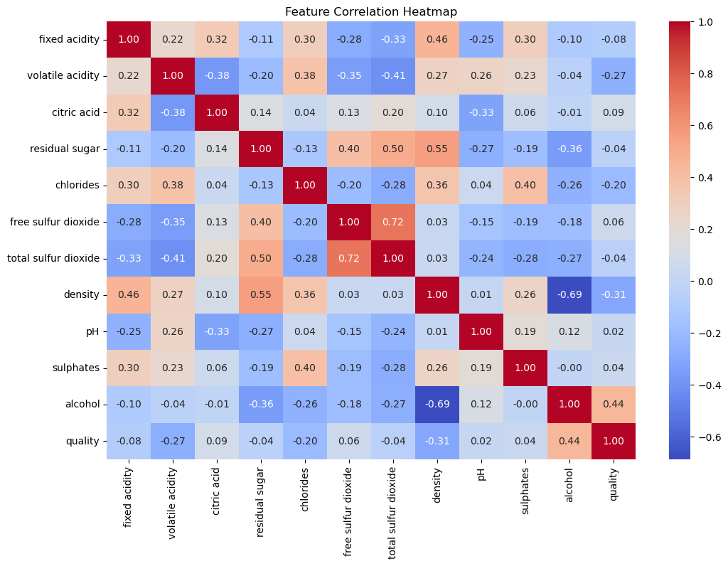

```python
#Selecting numeric columns for correlation analysis
numeric_columns=data.select_dtypes(include=['int64','float64']).columns
numeric_data = data[numeric_columns]
correlation_matrix = numeric_data.corr()
#Visualising the correlation matrix using heatmap for numerical data.
plt.figure(figsize=(12, 8))
sns.heatmap(correlation_matrix, annot=True, cmap='coolwarm', fmt=".2f")
plt.title("Feature Correlation Heatmap")
plt.show()
```

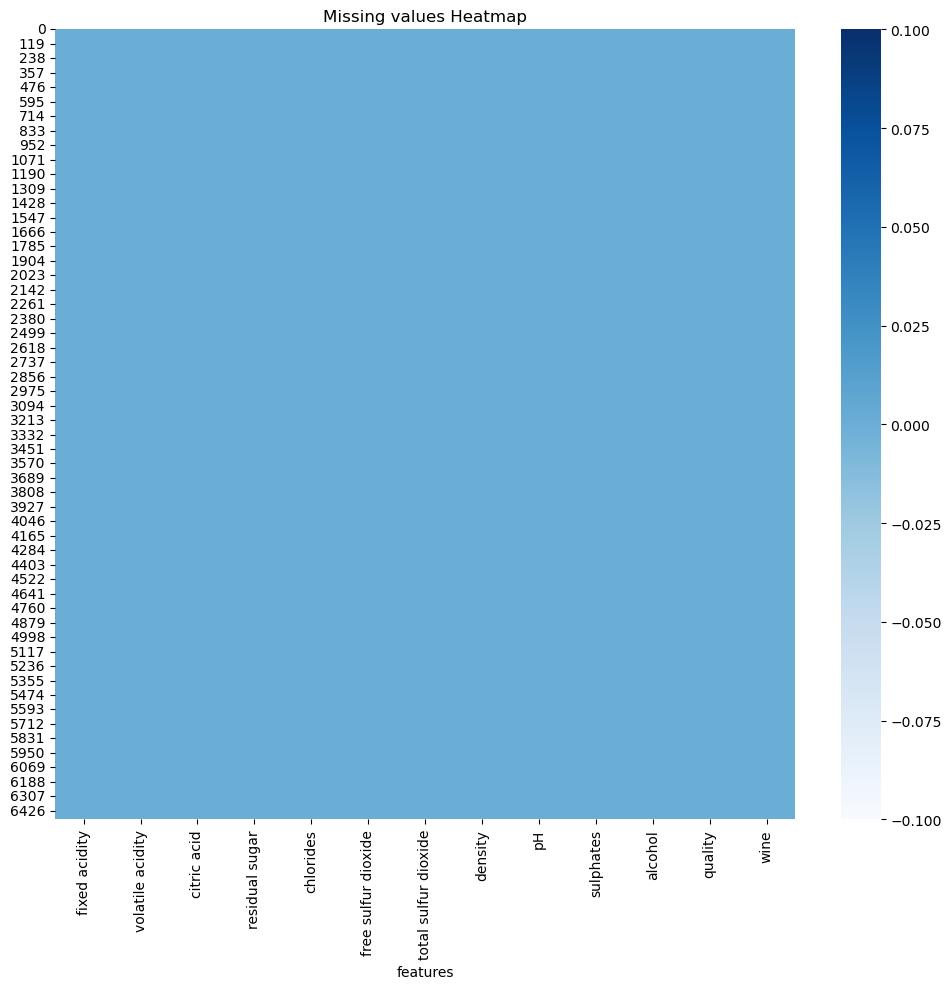

```python
#Creating heatmap for checking missing Values
plt.figure(figsize=(10, 10),tight_layout=True)
sns.heatmap(data.isnull(),cmap='Blues')
plt.title('Missing values Heatmap')
plt.xlabel('features')
plt.tight_layout()
plt.show()
```

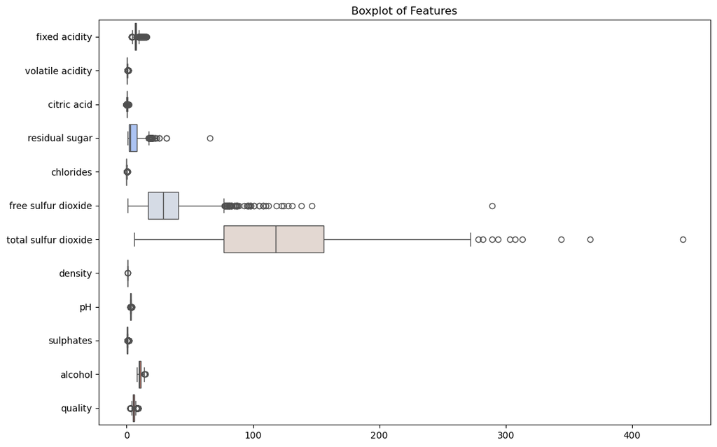

```python
#Creating Boxplot for examining outliers
plt.figure(figsize=(12, 8))
sns.boxplot(data=data, orient='h', palette='coolwarm')
plt.title('Boxplot of Features')
plt.show()
```

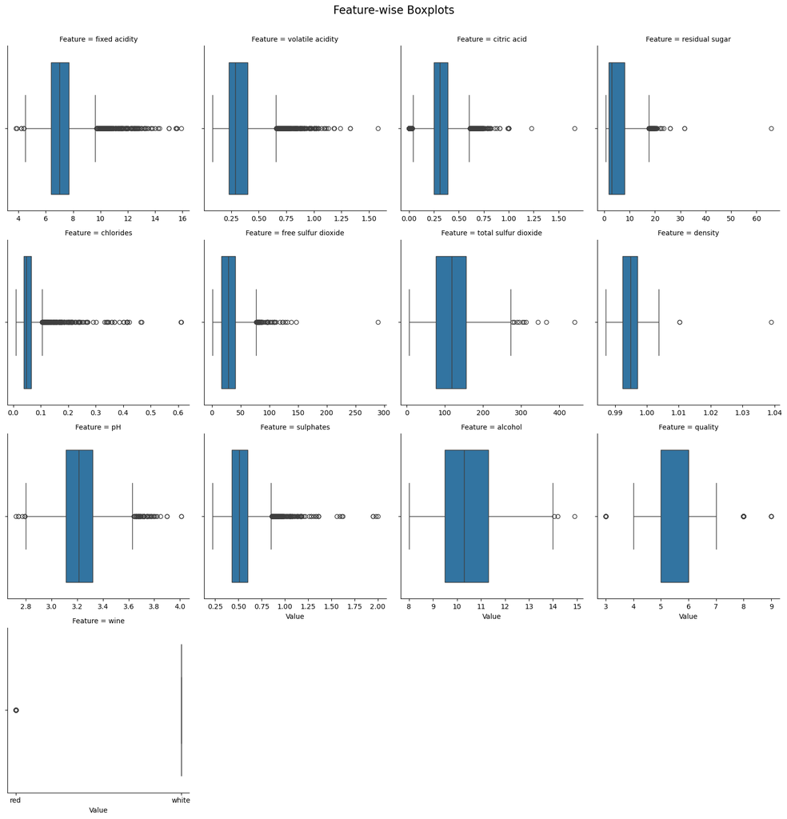

```python
#creating boxplot for each features for outliers detection
extracted_features = data.melt(var_name='Feature', value_name='Value')
grid = sns.FacetGrid(extracted_features, col="Feature", col_wrap=4, height=4, sharex=False, sharey=False)
grid.map(sns.boxplot, "Value")
grid.fig.suptitle("Feature-wise Boxplots", y=1.03, fontsize=16)
plt.show()
```

```
array([[<Axes: title={'center': 'fixed acidity'}>,
        <Axes: title={'center': 'volatile acidity'}>,
        <Axes: title={'center': 'citric acid'}>],
       [<Axes: title={'center': 'residual sugar'}>,
        <Axes: title={'center': 'chlorides'}>,
        <Axes: title={'center': 'free sulfur dioxide'}>],
       [<Axes: title={'center': 'total sulfur dioxide'}>,
        <Axes: title={'center': 'density'}>,
        <Axes: title={'center': 'pH'}>],
       [<Axes: title={'center': 'sulphates'}>,
        <Axes: title={'center': 'alcohol'}>,
        <Axes: title={'center': 'quality'}>]], dtype=object)
```

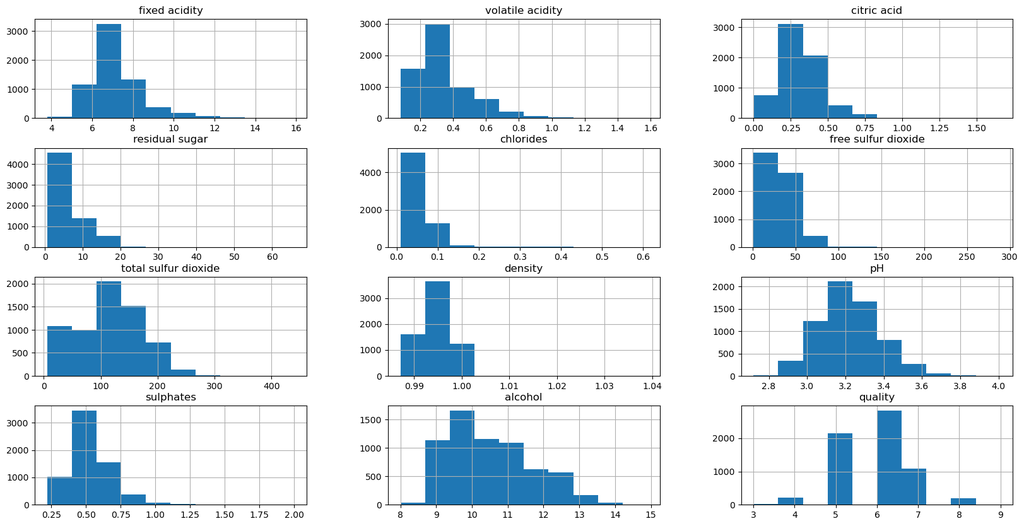

```python
# Creating histogram for visualizing distribution/spread of data for skewness
data.hist(figsize=(20,10))
```

## FEATURE ENGINEERING

Feature Engineering is the process of modifying or creating new features from existing data to improve the performance of algorithms.

```python
#initializing criteria for data classification
def quality_classification(quality):
     if quality > 7 :
        return 'Good'
     else :
         return 'Bad'
```

```python
#creating a new column from existing data.
data['classified_quality']=data['quality'].apply(quality_classification)
data.head()
```

|  | fixed acidity | volatile acidity | citric acid | residual sugar | chlorides | free sulfur dioxide | total sulfur dioxide | density | pH | sulphates | alcohol | quality | wine | classified_quality |
| --- | --- | --- | --- | --- | --- | --- | --- | --- | --- | --- | --- | --- | --- | --- |
| 0 | 7.4 | 0.70 | 0.00 | 1.9 | 0.076 | 11.0 | 34.0 | 0.9978 | 3.51 | 0.56 | 9.4 | 5 | red | Bad |
| 1 | 7.8 | 0.88 | 0.00 | 2.6 | 0.098 | 25.0 | 67.0 | 0.9968 | 3.20 | 0.68 | 9.8 | 5 | red | Bad |
| 2 | 7.8 | 0.76 | 0.04 | 2.3 | 0.092 | 15.0 | 54.0 | 0.9970 | 3.26 | 0.65 | 9.8 | 5 | red | Bad |
| 3 | 11.2 | 0.28 | 0.56 | 1.9 | 0.075 | 17.0 | 60.0 | 0.9980 | 3.16 | 0.58 | 9.8 | 6 | red | Bad |
| 4 | 7.4 | 0.70 | 0.00 | 1.9 | 0.076 | 11.0 | 34.0 | 0.9978 | 3.51 | 0.56 | 9.4 | 5 | red | Bad |

```python
#Converting categorical values into numerical values
data_encoded= pd.get_dummies(data,columns=['wine','classified_quality'])
data_encoded.head()
```

|  | fixed acidity | volatile acidity | citric acid | residual sugar | chlorides | free sulfur dioxide | total sulfur dioxide | density | pH | sulphates | alcohol | quality | wine_red | wine_white | classified_quality_Bad | classified_quality_Good |
| --- | --- | --- | --- | --- | --- | --- | --- | --- | --- | --- | --- | --- | --- | --- | --- | --- |
| 0 | 7.4 | 0.70 | 0.00 | 1.9 | 0.076 | 11.0 | 34.0 | 0.9978 | 3.51 | 0.56 | 9.4 | 5 | True | False | True | False |
| 1 | 7.8 | 0.88 | 0.00 | 2.6 | 0.098 | 25.0 | 67.0 | 0.9968 | 3.20 | 0.68 | 9.8 | 5 | True | False | True | False |
| 2 | 7.8 | 0.76 | 0.04 | 2.3 | 0.092 | 15.0 | 54.0 | 0.9970 | 3.26 | 0.65 | 9.8 | 5 | True | False | True | False |
| 3 | 11.2 | 0.28 | 0.56 | 1.9 | 0.075 | 17.0 | 60.0 | 0.9980 | 3.16 | 0.58 | 9.8 | 6 | True | False | True | False |
| 4 | 7.4 | 0.70 | 0.00 | 1.9 | 0.076 | 11.0 | 34.0 | 0.9978 | 3.51 | 0.56 | 9.4 | 5 | True | False | True | False |

### FEATURE SELECTION

Feature Selection simply means selecting the most important features or influencing features for training model and removing or discarding less important features which can cause complexity with data

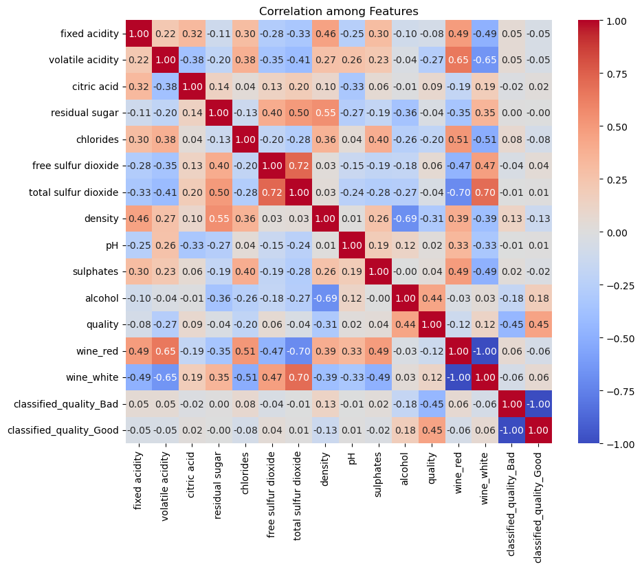

```python
#checking correlation between features
correlation_matrix = data_encoded.corr()
plt.figure(figsize=(10, 8))
sns.heatmap(correlation_matrix, annot=True, fmt=".2f", cmap='coolwarm', cbar=True)
plt.title('Correlation among Features')
plt.show()
```

```python
#removing less relevent and heavily correlated features
data_encoded = data_encoded.drop(columns=['wine_white','classified_quality_Bad','total sulfur dioxide','residual sugar','pH',
                                          'chlorides','quality'])
```

```python
#separating dependent features and independent features for model training.
independent_features = data_encoded.drop(columns=['classified_quality_Good'])
dependent_feature = data_encoded['classified_quality_Good']
```

```python
x= independent_features
y= dependent_feature
```

### DATA BALANCING

Data balancing is the process of managing the classes so that the distribution is more even. It is crucial as one class may be overrepresented than the other class causing imbalance and poor performance of the model

```python
#Using SMOTE for oversampling the underrepresented class
smote = SMOTE(sampling_strategy='auto', random_state=42)
x_resampled, y_resampled = smote.fit_resample(x, y)
```

```python
#Checking skewness of independent features
skewness_xr = x_resampled.skew()
skewness_xr
```

```
fixed acidity          1.748346
volatile acidity       1.705365
citric acid            0.464965
free sulfur dioxide    1.132310
density                0.697075
sulphates              1.402042
alcohol               -0.120727
wine_red               1.644276
dtype: float64
```

```python
#checking skewness of dependent feature
skewness_y=y.skew()
skewness_y
```

```
5.464279578075046
```

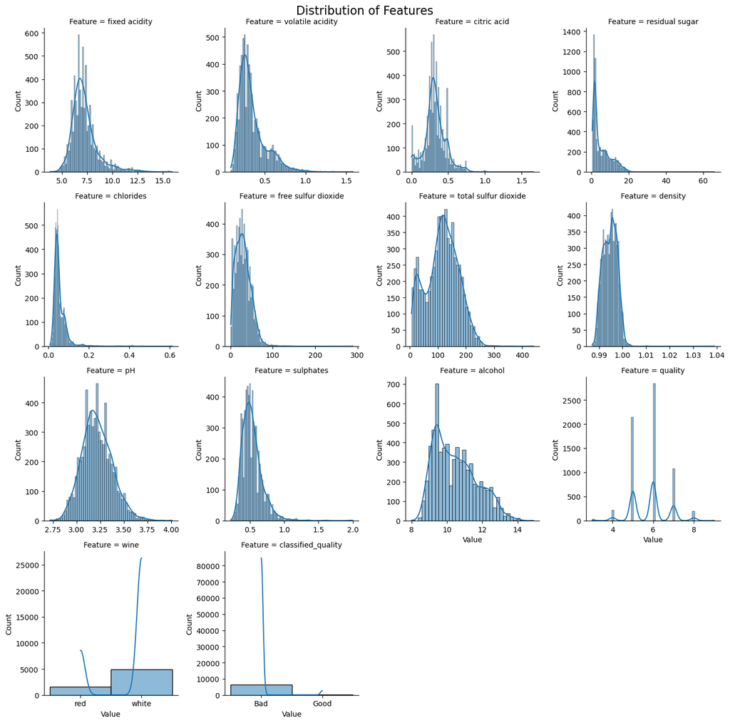

```python
#Visualizing skewness
extracted_features = data.melt(var_name='Feature', value_name='Value')
grid = sns.FacetGrid(extracted_features, col="Feature", col_wrap=4, height=3.5, sharex=False, sharey=False)
grid.map(sns.histplot, "Value", kde=True)
grid.fig.suptitle("Distribution of Features",  fontsize=16)
grid.tight_layout()
plt.show()
```

## PREPARING FOR MODEL TRAINING

```python
from sklearn.model_selection import train_test_split
```

```python
#Splitting the data into training and testing subset
x_train,x_test,y_train,y_test = train_test_split(x_resampled,y_resampled,test_size=0.2,random_state=42)
```

### FEATURE SCALING

Feature scaling is the process of normalizing/standardizing the range of features in the dataset meaning that features can be represented in different scales such as if one feature is represented in dollars and another in liter the model may prioritize one feature over another.

```python
#Standarizing the data so that the features are on same scale
scaler=StandardScaler()
scaled_x_train = scaler.fit_transform(x_train) #measuring the scale and tranforming training data
scaled_x_test= scaler.transform(x_test) # transforming the test set into same scale as training set
```

### MODEL IMPLEMENTATION

After splitting, the data are fitted into chosen algorithms such as Support Vector Machine (SVM), Decision Tree Classifier and Bagging Classifier. The model trains according to training data and learn hidden patterns and relationships between the independent and (target) dependent feature

```python
#Training SVM model without hyperparameter tuning
#initializing the SVM model.
svm_model = SVC(random_state=42)
svm_model.fit(scaled_x_train, y_train)
svm_pred = svm_model.predict(scaled_x_test)
svm_accuracy = accuracy_score(y_test, svm_pred)
print(f"SVM Accuracy: {svm_accuracy:.2f}")

#checking if the model is overfitting
#condition: if training accuracy - testing accuracy >5 =Overfitting
y_train_pred = svm_model.predict(x_train)
train_accuracy = accuracy_score(y_train, y_train_pred)
print(f"Training Accuracy: {train_accuracy:.4f}")
print(f"Testing Accuracy: {svm_accuracy:.4f}")
```

```
SVM Accuracy: 0.87
Training Accuracy: 0.4962
Testing Accuracy: 0.8690
```

```python
#Training SVM model with hyperparameter tuning using GridSearch
#initializing the hyperparameter
svm_grid_param = {
    'C': [0.1, 1, 10, 50],
    'kernel': ['linear', 'rbf', 'poly'],
    'gamma': ['scale', 'auto'],
    }
svm_grid = GridSearchCV(SVC(random_state=42), param_grid=svm_grid_param, scoring='accuracy', cv=5)
svm_grid.fit(scaled_x_train, y_train)
grid_svm_model = svm_grid.best_estimator_
grid_svm_pred = grid_svm_model.predict(scaled_x_test)
grid_svm_accuracy = accuracy_score(y_test,grid_svm_pred)
print(f"Best SVM Parameters: {svm_grid.best_params_}")
grid_svm_accuracy = accuracy_score(y_test, grid_svm_pred)
print(f"Grid SVM Accuracy: {grid_svm_accuracy:.2f}")
#checking if the model is overfitting
#condition: if training accuracy - testing accuracy >5 =Overfitting
y_train_pred = grid_svm_model.predict(scaled_x_train)
train_accuracy = accuracy_score(y_train, y_train_pred)
print(f"Training Accuracy: {train_accuracy:.4f}")
print(f"Testing Accuracy: {grid_svm_accuracy:.4f}")
```

```
Best SVM Parameters: {'C': 50, 'gamma': 'scale', 'kernel': 'rbf'}
Grid SVM Accuracy: 0.93
Training Accuracy: 0.9352
Testing Accuracy: 0.9321
```

```python
#initializing the Decision Tree model.
tree_model = DecisionTreeClassifier( random_state=42, max_depth=10, min_samples_split=20, min_samples_leaf=10)
tree_model.fit(x_train, y_train)
tree_pred = tree_model.predict(x_test)
tree_accuracy = accuracy_score(y_test, tree_pred)
print(f"Decision Tree Accuracy: {tree_accuracy:.2f}")

#checking if the model is overfitted/underfitted
#condition: if training accuracy - testing accuracy >5 =Overfitting
y_train_pred = tree_model.predict(x_train)
train_accuracy = accuracy_score(y_train, y_train_pred)
print(f"Training Accuracy: {train_accuracy:.4f}")
print(f"Testing Accuracy: {tree_accuracy:.4f}")
```

```
Decision Tree Accuracy: 0.91
Training Accuracy: 0.9283
Testing Accuracy: 0.9115
```

```python
#initializing the base model as decision tree
bagging_model = BaggingClassifier(tree_model,n_estimators=300,random_state=42)
bagging_model.fit(x_train, y_train)
bagging_pred = bagging_model.predict(x_test)
bagging_accuracy = accuracy_score(y_test, bagging_pred)
print(f"Bagging Accuracy : {bagging_accuracy:.2f}")

#checking if the model is overfitted/underfitted
#condition: if training accuracy - testing accuracy >5 =Overfitting
y_train_pred = bagging_model.predict(x_train)
train_accuracy = accuracy_score(y_train, y_train_pred)
print(f"Training Accuracy: {train_accuracy:.4f}")
print(f"Testing Accuracy: {bagging_accuracy:.4f}")
```

```
Bagging Accuracy : 0.94
Training Accuracy: 0.9468
Testing Accuracy: 0.9357
```

### CONCLUSION

Comparative results of the model are summarized. ROC curves are visualised to highlight the models' performance to distinguish between classes.

```python
# Classification report of the models

print("SVM before hyperparameter tuning Performance Metrics:")
print(classification_report(y_test, svm_pred))

print("SVM after hyperparameter tuning Performance Metrics:")
print(classification_report(y_test, grid_svm_pred))

print("Decision Tree Performance Metrics:")
print(classification_report(y_test, tree_pred))

print("Bagging Classifier Performance Metrics:")
print(classification_report(y_test, bagging_pred))
```

```
SVM before hyperparameter tuning Performance Metrics:
              precision    recall  f1-score   support

       False       0.94      0.80      0.86      1298
        True       0.81      0.95      0.88      1222

    accuracy                           0.87      2520
   macro avg       0.88      0.87      0.87      2520
weighted avg       0.88      0.87      0.87      2520

SVM after hyperparameter tuning Performance Metrics:
              precision    recall  f1-score   support

       False       0.97      0.89      0.93      1298
        True       0.89      0.97      0.93      1222

    accuracy                           0.93      2520
   macro avg       0.93      0.93      0.93      2520
weighted avg       0.94      0.93      0.93      2520

Decision Tree Performance Metrics:
              precision    recall  f1-score   support

       False       0.95      0.87      0.91      1298
        True       0.88      0.95      0.91      1222

    accuracy                           0.91      2520
   macro avg       0.91      0.91      0.91      2520
weighted avg       0.91      0.91      0.91      2520

Bagging Classifier Performance Metrics:
              precision    recall  f1-score   support

       False       0.97      0.90      0.94      1298
        True       0.90      0.98      0.94      1222

    accuracy                           0.94      2520
   macro avg       0.94      0.94      0.94      2520
weighted avg       0.94      0.94      0.94      2520
```

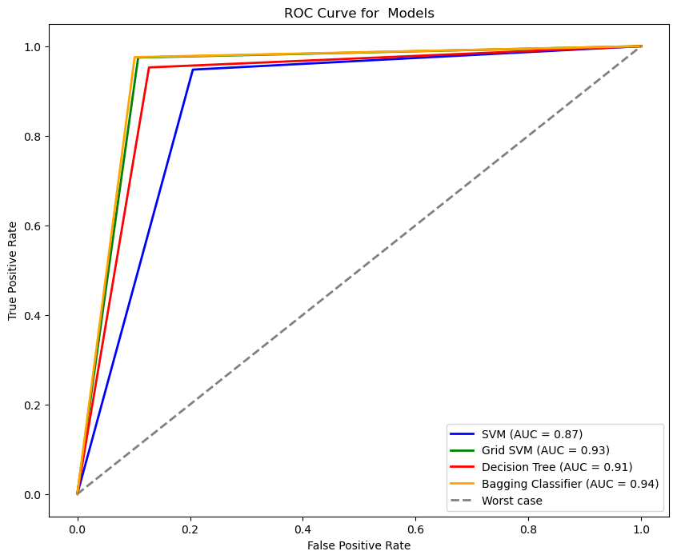

```python
# Create a figure for plotting the ROC curve
plt.figure(figsize=(10, 8))

# ROC and AUC for SVM before hyperparameter tuning
fpr_svm, tpr_svm, _ = roc_curve(y_test, svm_pred)
roc_auc_svm = auc(fpr_svm, tpr_svm)
plt.plot(fpr_svm, tpr_svm, color='blue', lw=2, label=f'SVM (AUC = {roc_auc_svm:.2f})')

# ROC and AUC for SVM after hyperparameter tuning
fpr_grid_svm, tpr_grid_svm,_= roc_curve(y_test, grid_svm_pred)
roc_auc_grid_svm = auc(fpr_grid_svm, tpr_grid_svm)
plt.plot(fpr_grid_svm, tpr_grid_svm, color='green', lw=2, label=f'Grid SVM (AUC = {roc_auc_grid_svm:.2f})')

# ROC and AUC for Decision Tree
fpr_tree, tpr_tree, _ = roc_curve(y_test, tree_pred)
roc_auc_tree = auc(fpr_tree, tpr_tree)
plt.plot(fpr_tree, tpr_tree, color='red', lw=2, label=f'Decision Tree (AUC = {roc_auc_tree:.2f})')

# ROC and AUC for Bagging Classifier
fpr_bagging, tpr_bagging, _ = roc_curve(y_test, bagging_pred)
roc_auc_bagging = auc(fpr_bagging, tpr_bagging)
plt.plot(fpr_bagging, tpr_bagging, color='orange', lw=2, label=f'Bagging Classifier (AUC = {roc_auc_bagging:.2f})')

# Adding the  line representing a worse model performance
plt.plot([0, 1], [0, 1], color='grey', lw=2, linestyle='--',label='Worst case')

# Adding plot labels and title

plt.xlabel('False Positive Rate')
plt.ylabel('True Positive Rate')
plt.title('ROC Curve for  Models')
plt.legend()
plt.show()
```

The ROC Curve is a visual representation of model performance across all thresholds.It shows the relationship between true positive rate and false positive rate. The Area under the curve (AUC) represents the probability that the model, if given a randomly chosen positive and negative example, will rank the positive higher than the negative. It summarizes the ROC curve in single number